# MSDS6306 Sect404

Steve Bramhall

September 23, 2018

## Live Assignment 4

#### Credit: https://www.analyticsvidhya.com/blog/2017/03/beginners-guide-on-web-scraping-in-r-using-rvest-with-hands-on-knowledge/

### 1. Harry Potter Cast (50%)

#### (a) In the IMDB, there are listings of full cast members for movies. Navigate to http://www.imdb.com/title/tt1201607/fullcredits?ref_=tt_ql_1. Feel free to View Source to get a good idea of what the page looks like in code.

### COMPLETE

#### (b) Scrape the page with any R package that makes things easy for you. Of particular interest is the table of the Cast in order of crediting. Please scrape this table (you might have to fish it out of several of the tables from the page) and make it a data.frame() of the Cast in your R environment

```r
# Load Libraries
library(rvest)
library(dplyr)
```

```r
library(tidyr)
library(stringr)
library(knitr)
library(kableExtra)
library(ggplot2)
```

```r
# Get IMDB Cast Info
url <- read_html('http://www.imdb.com/title/tt1201607/fullcredits?ref_=tt_ql_1')
cast_table <- html_nodes(url,".cast_list") %>% html_table() %>% as.data.frame()
head(cast_table)
```

```
##   X1               X2  X3                         X4
## 1
## 2       Ralph Fiennes ...             Lord Voldemort
## 3      Michael Gambon ... Professor Albus Dumbledore
## 4        Alan Rickman ...    Professor Severus Snape
## 5    Daniel Radcliffe ...               Harry Potter
## 6        Rupert Grint ...                Ron Weasley
```

#### (c) Clean up the table • It should not have blank observations or rows, a row that should be column names, or just ‘…’

- It should have intuitive column names (ideally 2 to start – Actor and Character)
- In the film, Mr. Warwick plays two characters, which makes his row look a little weird. Please replace his character column with just “Griphook / Professor Filius Flitwick” to make it look better.
- One row might result in “Rest of cast listed alphabetically” – remove this observation.

```r
# Clean Cast Table
cast_table <- cast_table[,-1]               # remove empty column
cast_table <- cast_table[,-2]               # remove empty column
cast_table <- cast_table[-1,]               # remove empty row
cast_table <- cast_table[-92,]              # remove erroneous row
names(cast_table) <- c("Actor","Character") # rename table columns
cast_table[10,2] <- 'Griphook / Professor Filius Flitwick' # fix Mr. Warwick
head(cast_table,10)
```

```
##               Actor                            Character
## 2     Ralph Fiennes                       Lord Voldemort
## 3    Michael Gambon           Professor Albus Dumbledore
## 4      Alan Rickman              Professor Severus Snape
## 5  Daniel Radcliffe                         Harry Potter
## 6      Rupert Grint                          Ron Weasley
## 7       Emma Watson                     Hermione Granger
## 8      Evanna Lynch                        Luna Lovegood
## 9  Domhnall Gleeson                         Bill Weasley
## 10   Clémence Poésy                       Fleur Delacour
## 11    Warwick Davis Griphook / Professor Filius Flitwick
```

#### (d) Split the Actor’s name into two columns: FirstName and Surname. Keep in mind that some actors/actresses have middle names as well. Please make sure that the middle names are in the FirstName column, in addition to the first name (example: given the Actor Frank Jeffrey Stevenson, the FirstName column would say “Frank Jeffrey.”)

```r
# Split Actor into FirstName and Surname
cast_table <- separate(cast_table,"Actor",into=c("FirstName","Surname"),"(\\s+)(?!.*\\s+)")
```

#### (e) Present the first 10 rows of the data.frame() – It should have only FirstName, Surname, and Character columns.

```r
# Show first 10 rows using knitr::kable for added styling
kable(head(cast_table,10), align='l', row.names = F) %>% kable_styling(bootstrap_options = "striped", full_width = T)
```

| FirstName | Surname | Character |
| --- | --- | --- |
| Ralph | Fiennes | Lord Voldemort |
| Michael | Gambon | Professor Albus Dumbledore |
| Alan | Rickman | Professor Severus Snape |
| Daniel | Radcliffe | Harry Potter |
| Rupert | Grint | Ron Weasley |
| Emma | Watson | Hermione Granger |
| Evanna | Lynch | Luna Lovegood |
| Domhnall | Gleeson | Bill Weasley |
| Clémence | Poésy | Fleur Delacour |
| Warwick | Davis | Griphook / Professor Filius Flitwick |

### 2. SportsBall (50%)

#### (a) On the ESPN website, there are statistics of each NBA player. Navigate to the San Antonio Spurs current statistics (likely http://www.espn.com/nba/team/stats/_/name/sa/san-antonio-spurs). You are interested in the Shooting Statistics table.

### COMPLETE

#### (b) Scrape the page with any R package that makes things easy for you. There are a few tables on the page, so make sure you are targeting specifically the Shooting Statistics table.

```r
# Get Spurs Shooting Stats Table
url <- read_html('http://www.espn.com/nba/team/stats/_/name/sa/san-antonio-spurs')
stats_table <- html_nodes(url,"table") %>% .[2] %>% html_table() %>% as.data.frame()
head(stats_table)
```

```
##                      X1                  X2                  X3
## 1   SHOOTING STATISTICS SHOOTING STATISTICS SHOOTING STATISTICS
## 2                PLAYER                 FGM                 FGA
## 3 LaMarcus Aldridge, PF                 7.4                16.0
## 4       Patty Mills, PG                 5.0                11.4
## 5          Rudy Gay, SF                 5.2                13.0
## 6      Manu Ginobili, G                 3.0                 7.4
##                    X4                  X5                  X6
## 1 SHOOTING STATISTICS SHOOTING STATISTICS SHOOTING STATISTICS
## 2                 FG%                 3PM                 3PA
## 3                .463                 0.6                 1.0
## 4                .439                 2.6                 7.0
## 5                .400                 0.8                 3.6
## 6                .405                 1.2                 3.6
##                    X7                  X8                  X9
```

[output cut: 20 more lines]

#### (c) Clean up the table (You might get some warnings if you’re working with tibbles) • You’ll want to create an R data.frame() with one observation for each player. Make sure that you do not accidentally include blank rows, a row of column names, or the Totals row in the table as observations.

```r
# Clean Stats Table
spurs_table <- stats_table[-1,]                     # remove 1st row, put into spurs_table
colnames(spurs_table) = spurs_table[1,]             # make new 1st row the column names
spurs_table <- spurs_table[-1,]                     # remove the non-data row
spurs_table <- spurs_table[-(length(spurs_table)),] # remove totals row
head(spurs_table)
```

```
##                  PLAYER FGM  FGA  FG% 3PM 3PA  3P% FTM FTA  FT% 2PM  2PA
## 3 LaMarcus Aldridge, PF 7.4 16.0 .463 0.6 1.0 .600 8.2 8.4 0.98 6.8 15.0
## 4       Patty Mills, PG 5.0 11.4 .439 2.6 7.0 .371 0.8 1.0 0.80 2.4  4.4
## 5          Rudy Gay, SF 5.2 13.0 .400 0.8 3.6 .222 1.0 1.8 0.56 4.4  9.4
## 6      Manu Ginobili, G 3.0  7.4 .405 1.2 3.6 .333 1.8 2.2 0.82 1.8  3.8
## 7   Dejounte Murray, PG 2.8  6.2 .452 0.8 1.2 .667 1.4 1.8 0.78 2.0  5.0
## 8       Tony Parker, PG 2.8  7.4 .378 0.0 1.0 .000 1.0 1.4 0.71 2.8  6.4
##    2P%   PPS AFG%
## 3 .453 1.475 0.48
## 4 .545 1.175 0.55
## 5 .468  .938 0.43
## 6 .474 1.216 0.49
## 7 .400 1.258 0.52
## 8 .438  .892 0.38
```

- The column PLAYER has two variables of interest in it: the player’s name and their position, denoted by 1-2 letters after their name. Split the cells into two columns, one with Name and the other Position.

```r
# Split Player into Player and Position
spurs_table <- separate(spurs_table,"PLAYER",into=c("PLAYER","Position"),",")
head(spurs_table)
```

```
##              PLAYER Position FGM  FGA  FG% 3PM 3PA  3P% FTM FTA  FT% 2PM
## 3 LaMarcus Aldridge       PF 7.4 16.0 .463 0.6 1.0 .600 8.2 8.4 0.98 6.8
## 4       Patty Mills       PG 5.0 11.4 .439 2.6 7.0 .371 0.8 1.0 0.80 2.4
## 5          Rudy Gay       SF 5.2 13.0 .400 0.8 3.6 .222 1.0 1.8 0.56 4.4
## 6     Manu Ginobili        G 3.0  7.4 .405 1.2 3.6 .333 1.8 2.2 0.82 1.8
## 7   Dejounte Murray       PG 2.8  6.2 .452 0.8 1.2 .667 1.4 1.8 0.78 2.0
## 8       Tony Parker       PG 2.8  7.4 .378 0.0 1.0 .000 1.0 1.4 0.71 2.8
##    2PA  2P%   PPS AFG%
## 3 15.0 .453 1.475 0.48
## 4  4.4 .545 1.175 0.55
## 5  9.4 .468  .938 0.43
## 6  3.8 .474 1.216 0.49
## 7  5.0 .400 1.258 0.52
## 8  6.4 .438  .892 0.38
```

- Check the data type of all columns. Convert relevant columns to numeric. Check the data type of all columns again to confirm that they have changed!

```r
# Showing data types are all chr
str(spurs_table)
```

```
## 'data.frame':    14 obs. of  16 variables:
##  $ PLAYER  : chr  "LaMarcus Aldridge" "Patty Mills" "Rudy Gay" "Manu Ginobili" ...
##  $ Position: chr  " PF" " PG" " SF" " G" ...
##  $ FGM     : chr  "7.4" "5.0" "5.2" "3.0" ...
##  $ FGA     : chr  "16.0" "11.4" "13.0" "7.4" ...
##  $ FG%     : chr  ".463" ".439" ".400" ".405" ...
##  $ 3PM     : chr  "0.6" "2.6" "0.8" "1.2" ...
##  $ 3PA     : chr  "1.0" "7.0" "3.6" "3.6" ...
##  $ 3P%     : chr  ".600" ".371" ".222" ".333" ...
##  $ FTM     : chr  "8.2" "0.8" "1.0" "1.8" ...
##  $ FTA     : chr  "8.4" "1.0" "1.8" "2.2" ...
##  $ FT%     : chr  "0.98" "0.80" "0.56" "0.82" ...
##  $ 2PM     : chr  "6.8" "2.4" "4.4" "1.8" ...
##  $ 2PA     : chr  "15.0" "4.4" "9.4" "3.8" ...
##  $ 2P%     : chr  ".453" ".545" ".468" ".474" ...
##  $ PPS     : chr  "1.475" "1.175" ".938" "1.216" ...
##  $ AFG%    : chr  "0.48" "0.55" "0.43" "0.49" ...
```

```r
statheaders <- colnames(spurs_table)                            # Get all all column names
statheaders <- statheaders[3:length(statheaders)]               # Get stat names that need to be converted
spurs_table <-spurs_table %>% mutate_at(statheaders,as.double)  # Convert stat columns to double

# Showing data types are corrected
str(spurs_table)
```

```
## 'data.frame':    14 obs. of  16 variables:
##  $ PLAYER  : chr  "LaMarcus Aldridge" "Patty Mills" "Rudy Gay" "Manu Ginobili" ...
##  $ Position: chr  " PF" " PG" " SF" " G" ...
##  $ FGM     : num  7.4 5 5.2 3 2.8 2.8 2 2.4 1.3 1.6 ...
##  $ FGA     : num  16 11.4 13 7.4 6.2 7.4 4 4 4.3 6 ...
##  $ FG%     : num  0.463 0.439 0.4 0.405 0.452 0.378 0.5 0.6 0.294 0.267 ...
##  $ 3PM     : num  0.6 2.6 0.8 1.2 0.8 0 0.2 0 0.5 1 ...
##  $ 3PA     : num  1 7 3.6 3.6 1.2 1 0.6 0.8 2.3 4 ...
##  $ 3P%     : num  0.6 0.371 0.222 0.333 0.667 0 0.333 0 0.222 0.25 ...
##  $ FTM     : num  8.2 0.8 1 1.8 1.4 1 1.8 0.6 1.3 0 ...
##  $ FTA     : num  8.4 1 1.8 2.2 1.8 1.4 2 0.8 1.8 0 ...
##  $ FT%     : num  0.98 0.8 0.56 0.82 0.78 0.71 0.9 0.75 0.71 0 ...
##  $ 2PM     : num  6.8 2.4 4.4 1.8 2 2.8 1.8 2.4 0.8 0.6 ...
##  $ 2PA     : num  15 4.4 9.4 3.8 5 6.4 3.4 3.2 2 2 ...
##  $ 2P%     : num  0.453 0.545 0.468 0.474 0.4 0.438 0.529 0.75 0.375 0.3 ...
##  $ PPS     : num  1.475 1.175 0.938 1.216 1.258 ...
##  $ AFG%    : num  0.48 0.55 0.43 0.49 0.52 0.38 0.53 0.6 0.35 0.35 ...
```

#### (d) Create a colorful bar chart that shows the Field Goals Percentage Per Game for each person. It will be graded on the following criteria.

- Informative Title, centered
- Relevant x and y axis labels (not simply variables names!)
- Human-readable axes with no overlap (you might have to flip x and y to fix that). Note: You do not have to convert the decimal to a percentage.
- Color the columns by the team member’s position (so, all PF’s should have the same color, etc.)

```r
plotdata <- data.frame("Player" = spurs_table$PLAYER,
                       "FG" = spurs_table$`FG%`,
                       "Position" = spurs_table$Position,
                       stringsAsFactors = FALSE)
plotdata
```

```
##               Player    FG Position
## 1  LaMarcus Aldridge 0.463       PF
## 2        Patty Mills 0.439       PG
## 3           Rudy Gay 0.400       SF
## 4      Manu Ginobili 0.405        G
## 5    Dejounte Murray 0.452       PG
## 6        Tony Parker 0.378       PG
## 7          Pau Gasol 0.500        C
## 8      Kyle Anderson 0.600       SF
## 9        Bryn Forbes 0.294       SG
## 10       Danny Green 0.267       SG
## 11     Davis Bertans 0.167        C
## 12     Derrick White 0.500       PG
## 13 Joffrey Lauvergne 1.000        C
## 14      Brandon Paul 0.000        G
```

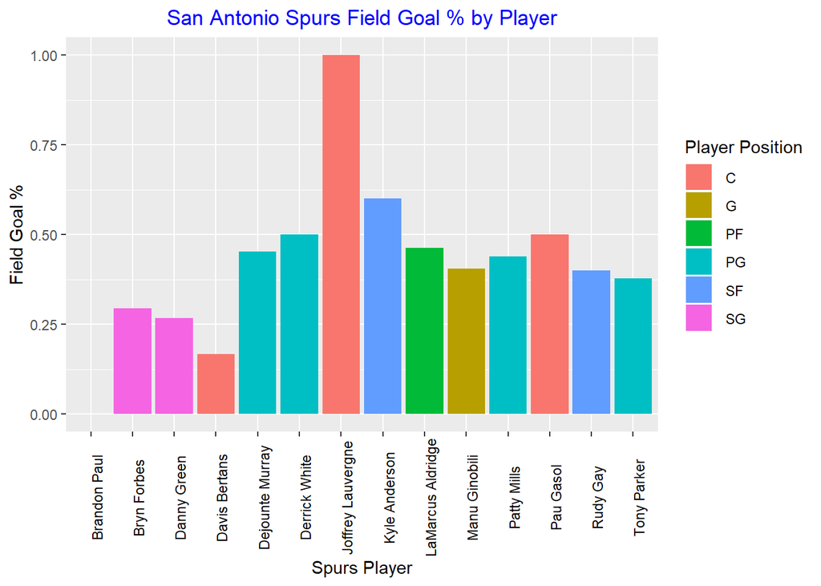

```r
ggplot(plotdata) + aes(x=Player,y=FG,fill=plotdata$Position) + geom_bar(stat="identity") +
  theme(axis.text.x=element_text(angle=90,color="black")) +
  labs(title = "San Antonio Spurs Field Goal % by Player", x = "Spurs Player", y = "Field Goal %") +
  theme(plot.title = element_text(color="blue",hjust=0.5)) +
  guides(fill=guide_legend("Player Position"))
```